# Práctica 2: ¿Cómo realizar la limpieza y análisis de datos?

Balpreet Kaur Singh/Daniel Cañete Román

16 de junio 2023

# 0. Introdución y pasos iniciales

Esta práctica se ha realizado bajo el contexto de la asignatura **Tipología y ciclo de vida de los datos**, perteneciente al Máster en Ciencia de Datos de la Universitat Oberta de Catalunya. En ella, se aplican técnicas de **limpieza y análisis de datos** mediante el lenguaje de programación R.

Para facilitar la lectura se incorpora parte del enunciado utilizando el formato blockquote

Tras analizar el dataset resultante en la PRA1, se ha seleccionado el propuesto en el enunciado por tener mayor riqueza a nivel educativo.

# 1. Descripción del dataset

> ¿Por qué es importante y qué pregunta/problema pretende responder?

Corroboremos estos datos e indaguemos un poco más:

```r
head(ds) %>% gt()
```

| age | sex | cp | trtbps | chol | fbs | restecg | thalachh | exng | oldpeak | slp | caa | thall | output |
| --- | --- | --- | --- | --- | --- | --- | --- | --- | --- | --- | --- | --- | --- |
| 63 | 1 | 3 | 145 | 233 | 1 | 0 | 150 | 0 | 2.3 | 0 | 0 | 1 | 1 |
| 37 | 1 | 2 | 130 | 250 | 0 | 1 | 187 | 0 | 3.5 | 0 | 0 | 2 | 1 |
| 41 | 0 | 1 | 130 | 204 | 0 | 0 | 172 | 0 | 1.4 | 2 | 0 | 2 | 1 |
| 56 | 1 | 1 | 120 | 236 | 0 | 1 | 178 | 0 | 0.8 | 2 | 0 | 2 | 1 |
| 57 | 0 | 0 | 120 | 354 | 0 | 1 | 163 | 1 | 0.6 | 2 | 0 | 2 | 1 |
| 57 | 1 | 0 | 140 | 192 | 0 | 1 | 148 | 0 | 0.4 | 1 | 0 | 1 | 1 |

```r
summary (ds)
```

```
##       age             sex               cp            trtbps
##  Min.   :29.00   Min.   :0.0000   Min.   :0.000   Min.   : 94.0
##  1st Qu.:47.50   1st Qu.:0.0000   1st Qu.:0.000   1st Qu.:120.0
##  Median :55.00   Median :1.0000   Median :1.000   Median :130.0
##  Mean   :54.37   Mean   :0.6832   Mean   :0.967   Mean   :131.6
##  3rd Qu.:61.00   3rd Qu.:1.0000   3rd Qu.:2.000   3rd Qu.:140.0
##  Max.   :77.00   Max.   :1.0000   Max.   :3.000   Max.   :200.0
##       chol            fbs            restecg          thalachh
##  Min.   :126.0   Min.   :0.0000   Min.   :0.0000   Min.   : 71.0
##  1st Qu.:211.0   1st Qu.:0.0000   1st Qu.:0.0000   1st Qu.:133.5
##  Median :240.0   Median :0.0000   Median :1.0000   Median :153.0
##  Mean   :246.3   Mean   :0.1485   Mean   :0.5281   Mean   :149.6
##  3rd Qu.:274.5   3rd Qu.:0.0000   3rd Qu.:1.0000   3rd Qu.:166.0
##  Max.   :564.0   Max.   :1.0000   Max.   :2.0000   Max.   :202.0
##       exng           oldpeak          slp             caa
##  Min.   :0.0000   Min.   :0.00   Min.   :0.000   Min.   :0.0000
##  1st Qu.:0.0000   1st Qu.:0.00   1st Qu.:1.000   1st Qu.:0.0000
##  Median :0.0000   Median :0.80   Median :1.000   Median :0.0000
##  Mean   :0.3267   Mean   :1.04   Mean   :1.399   Mean   :0.7294
##  3rd Qu.:1.0000   3rd Qu.:1.60   3rd Qu.:2.000   3rd Qu.:1.0000
##  Max.   :1.0000   Max.   :6.20   Max.   :2.000   Max.   :4.0000
##      thall           output
##  Min.   :0.000   Min.   :0.0000
##  1st Qu.:2.000   1st Qu.:0.0000
##  Median :2.000   Median :1.0000
##  Mean   :2.314   Mean   :0.5446
##  3rd Qu.:3.000   3rd Qu.:1.0000
##  Max.   :3.000   Max.   :1.0000
```

```r
str(ds)
```

```
## 'data.frame':    303 obs. of  14 variables:
##  $ age     : int  63 37 41 56 57 57 56 44 52 57 ...
##  $ sex     : int  1 1 0 1 0 1 0 1 1 1 ...
##  $ cp      : int  3 2 1 1 0 0 1 1 2 2 ...
##  $ trtbps  : int  145 130 130 120 120 140 140 120 172 150 ...
##  $ chol    : int  233 250 204 236 354 192 294 263 199 168 ...
##  $ fbs     : int  1 0 0 0 0 0 0 0 1 0 ...
##  $ restecg : int  0 1 0 1 1 1 0 1 1 1 ...
##  $ thalachh: int  150 187 172 178 163 148 153 173 162 174 ...
##  $ exng    : int  0 0 0 0 1 0 0 0 0 0 ...
##  $ oldpeak : num  2.3 3.5 1.4 0.8 0.6 0.4 1.3 0 0.5 1.6 ...
##  $ slp     : int  0 0 2 2 2 1 1 2 2 2 ...
##  $ caa     : int  0 0 0 0 0 0 0 0 0 0 ...
##  $ thall   : int  1 2 2 2 2 1 2 3 3 2 ...
##  $ output  : int  1 1 1 1 1 1 1 1 1 1 ...
```

```r
print ("Valores ausentes:")
```

```
## [1] "Valores ausentes:"
```

```r
colSums(is.na(ds))
```

```
##      age      sex       cp   trtbps     chol      fbs  restecg thalachh
##        0        0        0        0        0        0        0        0
##     exng  oldpeak      slp      caa    thall   output
##        0        0        0        0        0        0
```

```r
print("Cadenas vacías")
```

```
## [1] "Cadenas vacías"
```

```r
colSums(ds=="")
```

```
##      age      sex       cp   trtbps     chol      fbs  restecg thalachh
##        0        0        0        0        0        0        0        0
##     exng  oldpeak      slp      caa    thall   output
##        0        0        0        0        0        0
```

```r
print (paste (nrow(ds) , " observaciones"))
```

```
## [1] "303  observaciones"
```

```r
print ("Valores diferentes de cp: ")
```

```
## [1] "Valores diferentes de cp: "
```

```r
unique (ds$cp)
```

```
## [1] 3 2 1 0
```

```r
print ("Valores diferentes de restecg: ")
```

```
## [1] "Valores diferentes de restecg: "
```

```r
unique (ds$restecg)
```

```
## [1] 0 1 2
```

```r
print ("Valores diferentes de slp: ")
```

```
## [1] "Valores diferentes de slp: "
```

```r
unique (ds$slp)
```

```
## [1] 0 2 1
```

```r
print ("Valores diferentes de caa: ")
```

```
## [1] "Valores diferentes de caa: "
```

```r
unique (ds$caa)
```

```
## [1] 0 2 1 3 4
```

```r
print ("Valores diferentes de thall: ")
```

```
## [1] "Valores diferentes de thall: "
```

```r
unique (ds$thall)
```

```
## [1] 1 2 3 0
```

```r
print ("Valores diferentes de sex: ")
```

```
## [1] "Valores diferentes de sex: "
```

```r
unique (ds$sex)
```

```
## [1] 1 0
```

```r
print ("Valores diferentes de fbs: ")
```

```
## [1] "Valores diferentes de fbs: "
```

```r
unique (ds$fbs)
```

```
## [1] 1 0
```

```r
print ("Valores diferentes de exng: ")
```

```
## [1] "Valores diferentes de exng: "
```

```r
unique (ds$exng)
```

```
## [1] 0 1
```

Hay 303 observaciones, inicialmente no hay valores ausentes. Respecto los 0, estos son valores aceptables entre los valores disponibles de atributo. Es decir, los valores “0” no significan ausencia de valor para el atributo especifico.

Los campos no son exactamente como aparece en la documentación, pero se puede encontrar una descripción más actualizada en https://www.kaggle.com/code/namanmanchanda/heart-attack-eda-prediction-90-accuracy:

# Tipo

age

Edad del paciente

int (29-77)

sex

Sexo del paciente

int (0 ó 1). No se indica qué significa cada cuál

cp

Tipo de dolor torácico

int (0, 1, 2 ó 3)

trtbps

Presión arterial en reposo (en mm Hg)

int (94-200)

chol

Colesterol en mg/dl obtenido a través del sensor BMI

int (126-564)

fbs

Azúcar en sangre en ayunas > 120 mg/dl (1 = verdadero; 0 = falso)

int (0 ó 1)

restecg

Electrocardiograma en reposo

- Valor 0: normal
- Valor 1: tener anomalías en la onda ST-T (inversiones de la onda T y/o elevación o depresión del ST > 0,05 mV)
- Valor 2: mostrar hipertrofia ventricular izquierda probable o definitiva según los criterios de Estes

int (0, 1 ó 2)

thalachh

Frecuencia cardíaca máxima alcanzada

int (71-202)

exng

Angina inducida por el ejercicio (1 = sí; 0 = no)

int (0 ó 1)

oldpeak

Pico anterior

num (0-6.2)

slp

Tendency Slope. Se refiere a la pendiente de una línea de tendencia.

int (0, 1 ó 2)

caa

Número de venas principales

int (0, 1, 2, 3 ó 4)

thall

Resultado de la prueba de esfuerzo con talio. Esta prueba es para comprobar si el flujo sanguineo a traves de las arterias coronarias es normal o no.

int (0, 1, 2 ó 3)

output

Variable objetivo. Es una codificación, no se define el significado de cada valor. Pero asumimos que :

- 0, no predispuesto a tener ataque cardíaco
- 1, predispuesto a tener ataque cardíaco

int (0 ó 1)

Vemos que tenemos:

- Una variable objetivo categórica: output
- Variables categóricas: sex, cp, fbs, restecg, exng, slp, caa y thall
- Variables numéricas: age, trtbps, chol, thalachh y oldpeak

**¿Por qué es importante y qué pregunta/problema pretende responder?**

Ahora conocemos un poco mejor los datos, podemos responder a la pregunta. Se trata de un dataset con información clínica de pacientes que están predispuestos o no a tener una angina de pecho. Evidentemente es muy interesante para crear un modelo predictivo, pero también para conocer qué variables hacen que una persona tenga más posibilidades de padecer una angina de pecho.

**Nota**: Hay algunos campos que no conocemos su significado concreto, pero aún así se pueden utilizar para el modelo. Si se detectan que son variables relacionadas con la variable objetivo, un experto puede describir su significado.

# 2. Integración y selección

> Integración y selección de los datos de interés a analizar. Puede ser el resultado de adicionar diferentes datasets o una subselección útil de los datos originales, en base al objetivo que se quiera conseguir.

La muestra no tiene un número elevado de registros que puedan dar problemas en el rendimiento en computación de analisis. En caso de que si la hubiera, habría que ver alguna manera de limitar los datos, al menos para facilitar los cálculos en fase de desarrollo (por ejemplo, limitar los atributos mediante PCA).

Respecto las observaciones y los datos en general, cuanto mayor observaciones tengamos, mejor nos acercaremos a los resultados y concluciones reales. Pero en nuestro caso, la muestra es pequeña. Por tanto, debemos de estudiar la muestra disponible para sacar las mejores conclusiones posibles.

Organizamos y buscamos duplicados:

```r
# Cambio de tipo variables clasificatorias
ds$sex <- as.factor(ds$sex)
ds$cp <- as.factor(ds$cp)
ds$fbs <- as.factor(ds$fbs)
ds$restecg <- as.factor(ds$restecg)
ds$exng <- as.factor(ds$exng)
ds$slp <- as.factor(ds$slp)
ds$caa <- as.factor(ds$caa)
ds$thall <- as.factor(ds$thall)
ds$output <- as.factor(ds$output)

# Cambio de variables numericas
ds$age <- as.numeric (ds$age)
ds$trtbps <- as.numeric (ds$trtbps)
ds$chol <- as.numeric (ds$chol)
ds$thalachh <- as.numeric (ds$thalachh)
ds$oldpeak <- as.numeric (ds$oldpeak)

# Ordenación de los campos (objetivo, clasificatorias y numéricas)
ds <- ds [, c ("output", "sex", "cp", "fbs", "restecg", "exng", "slp", "caa", "thall", "age", "trtbps", "chol", "thalachh", "oldpeak")]

# Comprobamos y quitamos los duplicados:
print(paste ("Duplicados:", nrow(ds[duplicated(ds), ]), "duplicados"))
```

```
## [1] "Duplicados: 1 duplicados"
```

```r
ds<-ds[!duplicated(ds), ]
print(paste ("Duplicados despues de limpieza:", nrow(ds[duplicated(ds), ]), "duplicados"))
```

```
## [1] "Duplicados despues de limpieza: 0 duplicados"
```

Se considera poco probable que haya dos observaciones exactamente iguales y, aunque en un caso real sería recomendable que lo valorase un experto, se ha supuesto una errata a la hora de crear el dataset y se ha eliminado la observación repetida.

Vamos a estudiar un poco más los campos categóricos comparándolos con la variable objetivo:

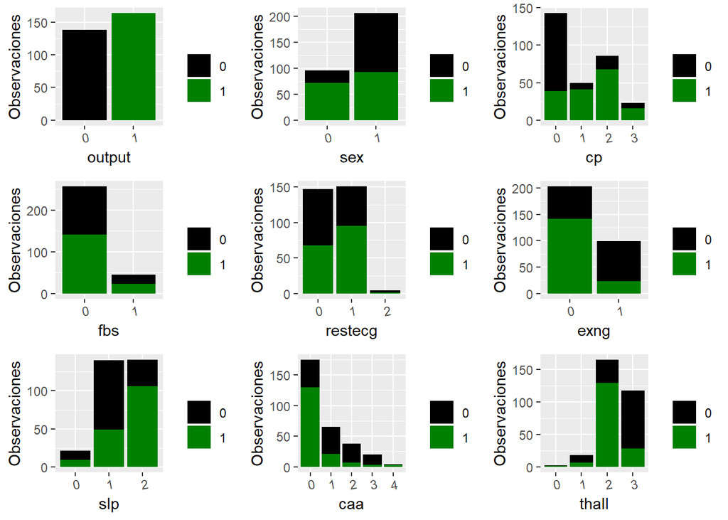

```r
myHistCat <- function(campo) {
  myPlot <- ggplot(ds, aes(x=ds[,campo], fill = output)) +
    geom_bar() + labs(x = campo, y = "Observaciones") +
    guides(fill = guide_legend(title = "")) +
    scale_fill_manual(values = c("black", "#008000")) +
    theme(axis.text.x = element_text(angle = 10, vjust = 1, hjust=0.5))
  return (myPlot)
}

grid.arrange(myHistCat("output"), myHistCat("sex"), myHistCat("cp"),
             myHistCat("fbs"), myHistCat("restecg"), myHistCat("exng"),
             myHistCat("slp"), myHistCat("caa"), myHistCat("thall"),
             ncol = 3, nrow = 3)
```

Sorprende que hay más personas predispuestas de las que no (164/138). Eso hace pensar que **la muestra está sesgada**, seguramente se ha obtenido entre pacientes que tenían alguna patología. Por eso se considera que **el estudio puede servir para detectar factores de riesgo, pero no se pueden sacar conclusiones a nivel de población general**,

Se observan también algunos valores posibles de variables con muy pocas observaciones, por lo que será difícil que sean significativos en un modelo predictivo. Este es el caso, por ejemplo:

```r
for (i in 1:9) {
  vName <- names(ds)[i]
  print (vName)
  print (table(ds[,i], ds$output))
}
```

```
## [1] "output"
##
##       0   1
##   0 138   0
##   1   0 164
## [1] "sex"
##
##       0   1
##   0  24  72
##   1 114  92
## [1] "cp"
##
##       0   1
##   0 104  39
##   1   9  41
```

[output cut: 39 more lines]

Estudiemos los valores numéricos:

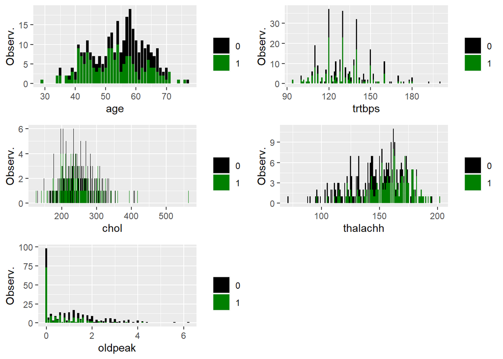

```r
myHistNum <- function(campo) {
  myPlot <- ggplot(ds, aes(ds[,campo], fill = output)) +
    geom_bar() + labs(x = campo, y = "Observ.") +
    guides(fill = guide_legend(title = "")) +
    scale_fill_manual(values = c("black", "#008000"))
  return (myPlot)
}

grid.arrange(myHistNum("age"), myHistNum("trtbps"), myHistNum("chol"),
             myHistNum("thalachh"), myHistNum("oldpeak"),
             ncol = 2, nrow = 3)
```

Al analizar las distribuciones en los histogramas, podemos decir que las observaciones son mas frecuentes cuando:

- Picos anteriores (oldpeak) son más cercano a 0
- Frecuencia cardiaca (thalachh) con valores superiores a 140 y inferiores a 180.
- Presión arterial en reposo está entre 100 y 160 Hg.
- Colesterol esta entre 150 y 350 mg/dl segun BMI sensor
- Y edad entre 40 y 70 años.

Los histogramas presentados no nos permiten diferenciar comportamientos distintos dependiendo de la variable objetivo. Veamos en diagrams de cajas:

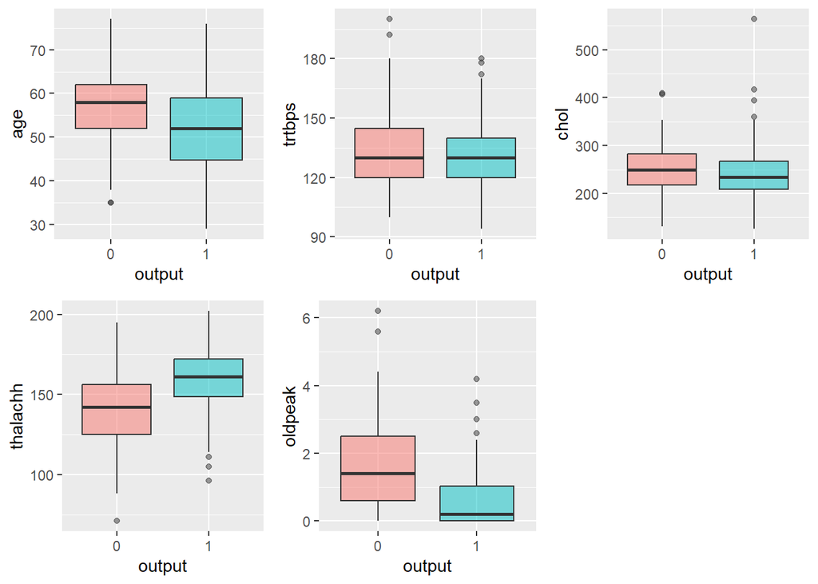

```r
myCaja <- function(campo) {
  myPlot <- ggplot(ds, aes(x=output, y=ds[,campo], fill=output)) +
    geom_boxplot(alpha=0.5) +
    labs(x = "output", y = campo) +
    theme(legend.position="none")
  return (myPlot)
}

grid.arrange(myCaja("age"), myCaja("trtbps"), myCaja("chol"),
             myCaja("thalachh"), myCaja("oldpeak"),
             ncol = 3, nrow = 2)
```

Se pueden intuir alguna correlación con la variable objetivo. Por ejemplo, parece que es más probable tener ataque al corazón (output = 1) cuando:

- Picos anteriores (oldpeak) son más cercano a 0
- Frecuencia cardiaca (thalachh) con valores entre 150y 170.

Estudiemos la correlación entre las variables. Si encontramos alguna muy relacionadas podemos quitarlas del modelo y reducir su complejidad:

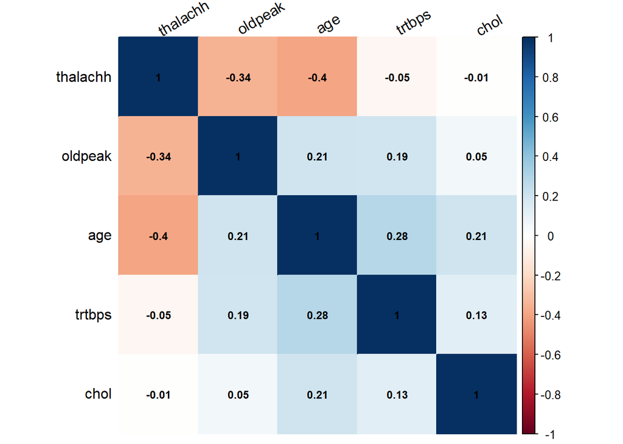

```r
n = c("age", "trtbps", "chol", "thalachh", "oldpeak")
factores= ds %>% select(all_of(n))
res<-cor(factores)
corrplot(res,method="color",tl.col="black", tl.srt=30, order = "AOE",
number.cex=0.75,sig.level = 0.01, addCoef.col = "black")
```

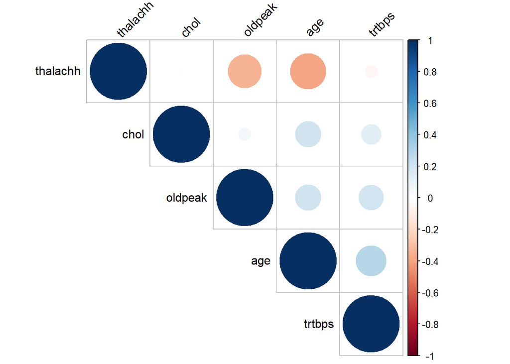

```r
matriz <- cor (ds[,n])
corrplot(matriz, type="upper", order="hclust", tl.col="black", tl.srt=45)
```

Observamos que no hay una alta correlación entre las variables por lo que no prescindiremos de ninguna.

# 3. Limpieza de los datos

> 3.1. ¿Los datos contienen ceros o elementos vacíos? Gestiona cada uno de estos casos

> 3.2. Identifica y gestiona los valores extremos

En el punto anterior se ha analizado el dataset y observando los resultados, ya podemos obtener algunas conclusiones sin necesidad de desarrollar más código:

- **No se aprecian valores ausentes**. Asumiendo que los datos son recogidos sin errores alguno, podemos afirmar que no hay ausencia de valores ya estos se suelen identifcar con:
  - “na” -> No se encuentra dicha cadena en el dataset
  - “0” -> En el caso de estudio, la mayoría de las variables tiene un significado concreto para ese valor y son recolectador y/o insertados sin transformación previa alguna.
- En los diagramas de cajas, vemos varios valores fuera de los rangos normales. Estos son valores extremos, pero no tienen por que ser erroneos (outliers), por lo que sería recomendable consultar a un experto antes de descartarlos. En nuestro caso entendemos todos como válidos excepto un caso que destaca: una **observación con extremadamente elevado, que está muy separada de los rangos normales**.

La gestión de valores atípicos (outlier management) es la ciencia de investigar y aplicar un tratamiento adecuado a los valores atípicos en los datos. Puede ser tentador simplemente eliminar los registros donde hay valores atípicos en el conjunto de datos, pero no siempre es el mejor enfoque. El método de tratamiento de valores atípicos puede variar de un caso a otro y debe discutirse con la empresa antes de finalizar el método. Existen diferentes enfoques, como **reemplazar el valor atípico con el valor medio o la mediana** o, en algunos casos, **descartar la observación con el valor atípico sospechoso para evitar cualquier sesgo en ellos**. Tendemos a eliminar los valores atípicos si se deben a errores de entrada de datos causados por errores humanos, errores de procesamiento de datos.

Vamos a gestionar el último valor extremo de Colestrol, del cual estamos seguros que es valor extremo inaceptable optando por sustituirlo por la media:

```r
max(ds$chol)
```

```
## [1] 564
```

```r
ds [ds$chol==max(ds$chol), ]
```

```
##    output sex cp fbs restecg exng slp caa thall age trtbps chol thalachh
## 86      1   0  2   0       0    0   1   0     3  67    115  564      160
##    oldpeak
## 86     1.6
```

```r
# El ultimo valor extremo de cholestrol lo sustituimos por la media al estar seguros de que es un valor outlier erroneo.
ds [ds$chol==max(ds$chol), ]$chol <- mean (ds$chol)
```

Con el siguiente código podríamos detectar otros valores extremos y candidatos a outliers. Como se ha comentado, lo ideal es revisar con un experto la estrategia a seguir:

```r
ds %>%
  arrange(desc(chol)) %>%
  slice(1:8)
```

```
##   output sex cp fbs restecg exng slp caa thall age trtbps chol thalachh oldpeak
## 1      1   0  2   1       0    0   2   1     2  65    140  417      157     0.8
## 2      0   0  0   0       0    1   1   2     3  56    134  409      150     1.9
## 3      0   0  0   0       0    0   1   3     3  63    150  407      154     4.0
## 4      1   0  0   0       0    0   1   0     2  62    140  394      157     1.2
## 5      1   0  2   0       0    0   2   0     2  65    160  360      151     0.8
## 6      1   0  0   0       1    1   2   0     2  57    120  354      163     0.6
## 7      0   1  0   0       1    1   1   1     3  55    132  353      132     1.2
## 8      1   0  1   0       1    0   2   0     2  55    132  342      166     1.2
```

# 4. Análisis de los datos

## 4.1. Selección de los grupos de datos

> Selección de los grupos de datos que se quieren analizar/comparar (p. ej., si se van a comparar grupos de datos, ¿cuáles son estos grupos y qué tipo de análisis se van a aplicar?)

Teniendo en cuenta a **output como la variable objetivo**, procederemos a compararla con los diferentes atributos. En los siguientes puntos procederemos a hacer los comparaciones entre siguientes grupos y estrategias:

- Output y atributos categóricos [‘sex’, ‘cp’, ‘fbs’, ‘restecg’,‘exng’,‘slp’, ‘caa’, ‘thall’]: tenemos **dos variables categóricas** y haremos un test de χ2 para ver si existen diferencias significativas entre los grupos definidos. Pero en nuestro caso, tenemos una **muestra pequeña**, por tanto, **usaremos Fisher Test**.
- Output y variables numéricas nominal [‘age’, ‘trtbps’, ‘chol’, ‘thalachh’, ‘oldpeak’]: comparamos una **variable categórica con otra numérica**. La estrategia será distinta según:
  - **si cumple normalidad y homocedasticidad con output -> aplicamos tStudent,**
  - **si no -> test de Mann-Whitney.**

## 4.2. Comprobación de la normalidad y homogeneidad de la varianza.

Comprobamos la normalidad y homogeneidad de la varianza:

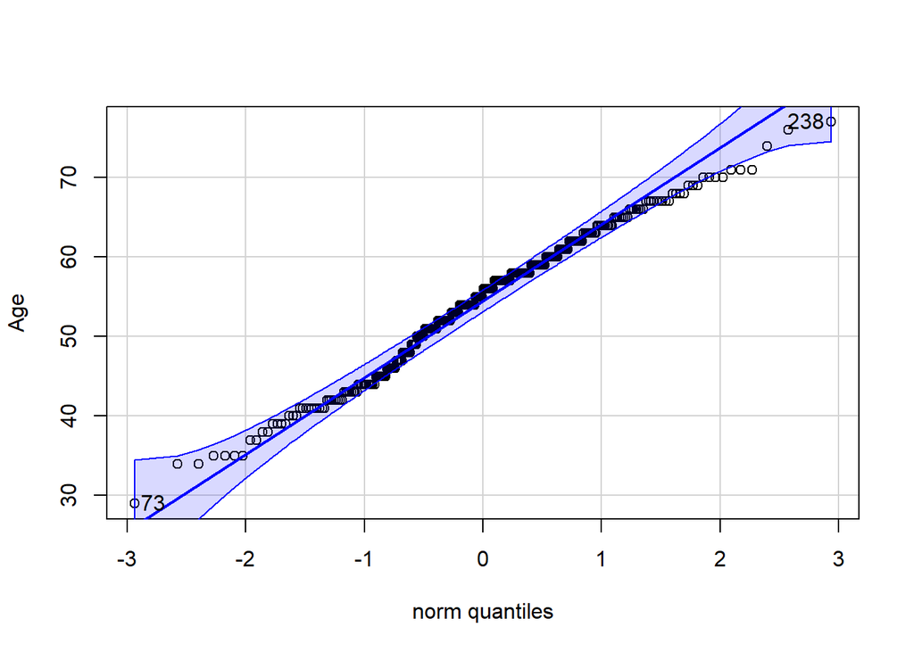

```
## [1]  73 238
```

```r
ds$age %>% qqPlot(dist="norm", ylab = "Age")
```

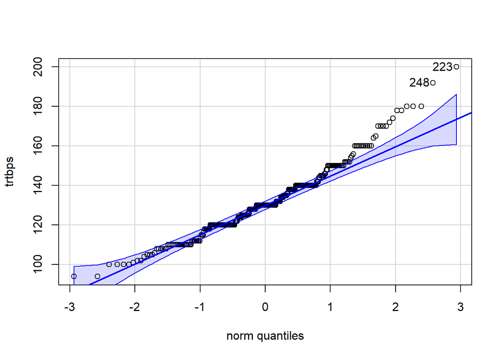

```
## [1] 223 248
```

```r
ds$trtbps %>% qqPlot(dist="norm", ylab = "trtbps")
```

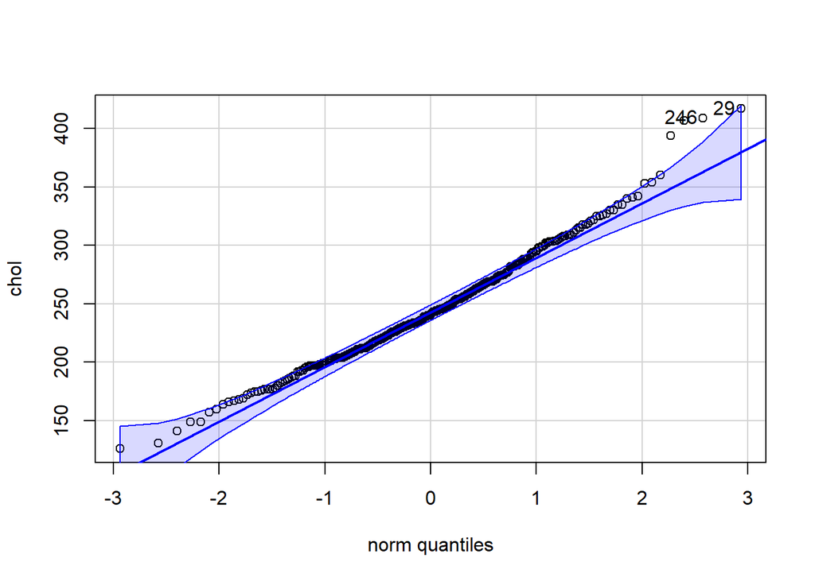

```
## [1]  29 246
```

```r
ds$chol %>% qqPlot(dist="norm", ylab = "chol")
```

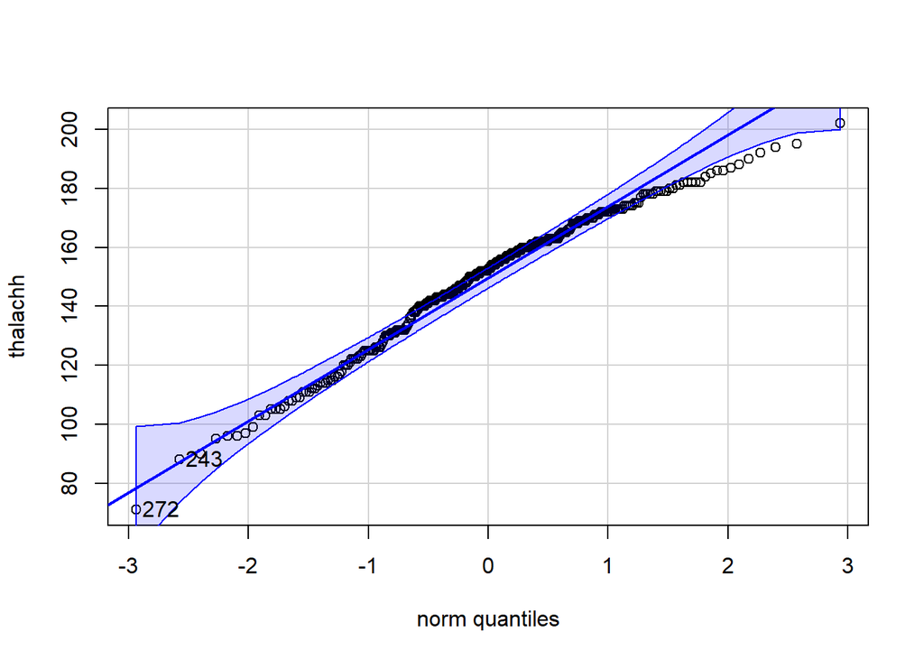

```
## [1] 272 243
```

```r
ds$thalachh %>% qqPlot(dist="norm", ylab = "thalachh")
```

[figure not shown]

```
## [1]  29 246
```

```r
ds$chol %>% qqPlot(dist="norm", ylab = "oldpeak")
```

```r
shapiro.test(ds$age)
```

```
##
##  Shapiro-Wilk normality test
##
## data:  ds$age
## W = 0.98664, p-value = 0.006745
```

```r
shapiro.test(ds$trtbps)
```

```
##
##  Shapiro-Wilk normality test
##
## data:  ds$trtbps
## W = 0.96573, p-value = 1.419e-06
```

```r
shapiro.test(ds$chol)
```

```
##
##  Shapiro-Wilk normality test
##
## data:  ds$chol
## W = 0.98277, p-value = 0.001079
```

```r
shapiro.test(ds$thalachh)
```

```
##
##  Shapiro-Wilk normality test
##
## data:  ds$thalachh
## W = 0.97679, p-value = 8.268e-05
```

```r
shapiro.test(ds$oldpeak)
```

```
##
##  Shapiro-Wilk normality test
##
## data:  ds$oldpeak
## W = 0.84522, p-value < 2.2e-16
```

Vemos que en todos los casos, el valor P es inferior a 0,05, lo que significa que **no podemos asumir normalidad en ninguno de las variables numéricas.**

Ahora veamos homogeneidad de varianza mediante Levene Test (no FTest) ya que no cumplimos el requisito de normalidad:

```r
leveneTest(age ~ output, data = ds)
```

```
## Levene's Test for Homogeneity of Variance (center = median)
##        Df F value   Pr(>F)
## group   1  7.6349 0.006079 **
##       300
## ---
## Signif. codes:  0 '***' 0.001 '**' 0.01 '*' 0.05 '.' 0.1 ' ' 1
```

```r
leveneTest(trtbps ~ output, data = ds)
```

```
## Levene's Test for Homogeneity of Variance (center = median)
##        Df F value Pr(>F)
## group   1  1.7911 0.1818
##       300
```

```r
leveneTest(chol ~ output, data = ds)
```

```
## Levene's Test for Homogeneity of Variance (center = median)
##        Df F value Pr(>F)
## group   1  0.8995 0.3437
##       300
```

```r
leveneTest(thalachh ~ output, data = ds)
```

```
## Levene's Test for Homogeneity of Variance (center = median)
##        Df F value  Pr(>F)
## group   1  5.1661 0.02374 *
##       300
## ---
## Signif. codes:  0 '***' 0.001 '**' 0.01 '*' 0.05 '.' 0.1 ' ' 1
```

```r
leveneTest(oldpeak ~ output, data = ds)
```

```
## Levene's Test for Homogeneity of Variance (center = median)
##        Df F value    Pr(>F)
## group   1  32.438 2.934e-08 ***
##       300
## ---
## Signif. codes:  0 '***' 0.001 '**' 0.01 '*' 0.05 '.' 0.1 ' ' 1
```

La prueba de Levene es una estadística inferencial utilizada para evaluar la igualdad de varianzas de una variable calculada para dos o más grupos. Para esta prueba, un valor p de menos de 0,05 indica que, de hecho, hay suficiente variación en la muestra para explicar las posibles diferencias de medias.

Cuando tenemos un valor de p por encima de 0.05 (nivel de significancia), podemos concluir que existe una no diferencia significativa entre las varianzas de la muestra probada y, por tanto nos encontramos con homogeniedad en la varianza. Según esto, nos encontramos con:

- Homogeniedad de las varianzas: trtbps, chol
- No homogeniedad de las varianzas: age, thalachh, oldpeak

Por tanto, **incumplimos la asunciones de que el dataset sea normal y tenga homogeneidad de varianza.**

## 4.3. Aplicación de pruebas estadísticas para comparar los grupos de datos.

> En función de los datos y el objetivo del estudio, aplicar pruebas de contraste de hipótesis, correlaciones, regresiones, etc. Aplicar al menos tres métodos de análisis diferentes.

### Fisher test

Debido a que tenemos un dataset pequeño (<1000) y ya hemos visto que no podemos asegurar normalidad, tenemos que utilizar fisher test para analizar la correlacion entre variables en vez de **Chi-cuadrado.**

Dado que vamos a hacer el mismo proceso con todas las variables clasificadoras, hacemos una función para facilitar código legible:

```r
myFishertest <- function (campo) {
  counts <- table(ds$output, ds[,campo])
  print (campo)
  print (counts / rowSums(counts))
  print (fisher.test(counts))
}
```

Este método nos ofrece una tabla de frecuencias y el resultado del test de fisher que puede sacar conclusiones sobre la tabla.

Si el resultado del fisher test nos da un p-value por debajo de su nivel de significación (p. ej., 0,05), se rechaza la hipótesis nula, o sea, que hay relación entre las variables.

Aplicamos el método con todas las variables categóricas:

```r
myFishertest ("sex")
```

```
## [1] "sex"
##
##             0         1
##   0 0.1739130 0.8260870
##   1 0.4390244 0.5609756
##
##  Fisher's Exact Test for Count Data
##
## data:  counts
## p-value = 1.01e-06
## alternative hypothesis: true odds ratio is not equal to 1
## 95 percent confidence interval:
##  0.1502637 0.4734676
## sample estimates:
## odds ratio
##  0.2701939
```

```r
myFishertest ("cp")
```

```
## [1] "cp"
##
##              0          1          2          3
##   0 0.75362319 0.06521739 0.13043478 0.05072464
##   1 0.23780488 0.25000000 0.41463415 0.09756098
##
##  Fisher's Exact Test for Count Data
##
## data:  counts
## p-value < 2.2e-16
## alternative hypothesis: two.sided
```

```r
myFishertest ("fbs")
```

```
## [1] "fbs"
##
##             0         1
##   0 0.8405797 0.1594203
##   1 0.8597561 0.1402439
##
##  Fisher's Exact Test for Count Data
##
## data:  counts
## p-value = 0.746
## alternative hypothesis: true odds ratio is not equal to 1
## 95 percent confidence interval:
##  0.433890 1.709881
## sample estimates:
## odds ratio
##  0.8605235
```

```r
myFishertest ("restecg")
```

```
## [1] "restecg"
##
##               0           1           2
##   0 0.572463768 0.405797101 0.021739130
##   1 0.414634146 0.579268293 0.006097561
##
##  Fisher's Exact Test for Count Data
##
## data:  counts
## p-value = 0.004462
## alternative hypothesis: two.sided
```

```r
myFishertest ("exng")
```

```
## [1] "exng"
##
##             0         1
##   0 0.4492754 0.5507246
##   1 0.8597561 0.1402439
##
##  Fisher's Exact Test for Count Data
##
## data:  counts
## p-value = 3.438e-14
## alternative hypothesis: true odds ratio is not equal to 1
## 95 percent confidence interval:
##  0.07309196 0.23880340
## sample estimates:
## odds ratio
##  0.1340885
```

```r
myFishertest ("slp")
```

```
## [1] "slp"
##
##              0          1          2
##   0 0.08695652 0.65942029 0.25362319
##   1 0.05487805 0.29878049 0.64634146
##
##  Fisher's Exact Test for Count Data
##
## data:  counts
## p-value = 1.769e-11
## alternative hypothesis: two.sided
```

```r
myFishertest ("caa")
```

```
## [1] "caa"
##
##               0           1           2           3           4
##   0 0.326086957 0.318840580 0.224637681 0.123188406 0.007246377
##   1 0.792682927 0.128048780 0.042682927 0.018292683 0.018292683
##
##  Fisher's Exact Test for Count Data
##
## data:  counts
## p-value < 2.2e-16
## alternative hypothesis: two.sided
```

```r
myFishertest ("thall")
```

```
## [1] "thall"
##
##               0           1           2           3
##   0 0.007246377 0.086956522 0.260869565 0.644927536
##   1 0.006097561 0.036585366 0.786585366 0.170731707
##
##  Fisher's Exact Test for Count Data
##
## data:  counts
## p-value < 2.2e-16
## alternative hypothesis: two.sided
```

```r
myFishertest ("output")
```

```
## [1] "output"
##
##     0 1
##   0 1 0
##   1 0 1
##
##  Fisher's Exact Test for Count Data
##
## data:  counts
## p-value < 2.2e-16
## alternative hypothesis: true odds ratio is not equal to 1
## 95 percent confidence interval:
##  3195.791      Inf
## sample estimates:
## odds ratio
##        Inf
```

Cuando su valor p esté por debajo de su nivel de significación (p. ej., 0,05), rechace la hipótesis nula. Los datos de la muestra son lo suficientemente fuertes como para concluir que existe una relación entre las variables categóricas en la población. Conocer el valor de una variable proporciona información sobre el valor de la otra variable.

A continuación, se resume las conclusiones obtenidas en la siguiente tabla:

[output not shown]

### Whitney

Ahora vamos a estudiar los atributos numéricos versus el output mediante mediante Whitney Wilcoxon Rank sum Test.

```r
str(ds[10:14])
```

```
## 'data.frame':    302 obs. of  5 variables:
##  $ age     : num  63 37 41 56 57 57 56 44 52 57 ...
##  $ trtbps  : num  145 130 130 120 120 140 140 120 172 150 ...
##  $ chol    : num  233 250 204 236 354 192 294 263 199 168 ...
##  $ thalachh: num  150 187 172 178 163 148 153 173 162 174 ...
##  $ oldpeak : num  2.3 3.5 1.4 0.8 0.6 0.4 1.3 0 0.5 1.6 ...
```

```r
wilcox.test(age ~ output, data=ds)
```

```
##
##  Wilcoxon rank sum test with continuity correction
##
## data:  age by output
## W = 14394, p-value = 4.626e-05
## alternative hypothesis: true location shift is not equal to 0
```

```r
wilcox.test(trtbps ~ output, data=ds)
```

```
##
##  Wilcoxon rank sum test with continuity correction
##
## data:  trtbps by output
## W = 12931, p-value = 0.03223
## alternative hypothesis: true location shift is not equal to 0
```

```r
wilcox.test(chol ~ output, data=ds)
```

```
##
##  Wilcoxon rank sum test with continuity correction
##
## data:  chol by output
## W = 12924, p-value = 0.03351
## alternative hypothesis: true location shift is not equal to 0
```

```r
wilcox.test(thalachh ~ output, data=ds)
```

```
##
##  Wilcoxon rank sum test with continuity correction
##
## data:  thalachh by output
## W = 5725, p-value = 1.398e-13
## alternative hypothesis: true location shift is not equal to 0
```

```r
wilcox.test(oldpeak ~ output, data=ds)
```

```
##
##  Wilcoxon rank sum test with continuity correction
##
## data:  oldpeak by output
## W = 16723, p-value = 3.347e-13
## alternative hypothesis: true location shift is not equal to 0
```

Con un nivel de significancia de .05, rechazamos hipótesis nula y podemos concluir que todos los atributos numéricos y la salida en el conjunto de datos provienen de poblaciones no idénticas. También que la diferencia entre la media de la población de salida y el atributo numérico correspondiente es estadísticamente significativa.

### Análisis de componentes principales

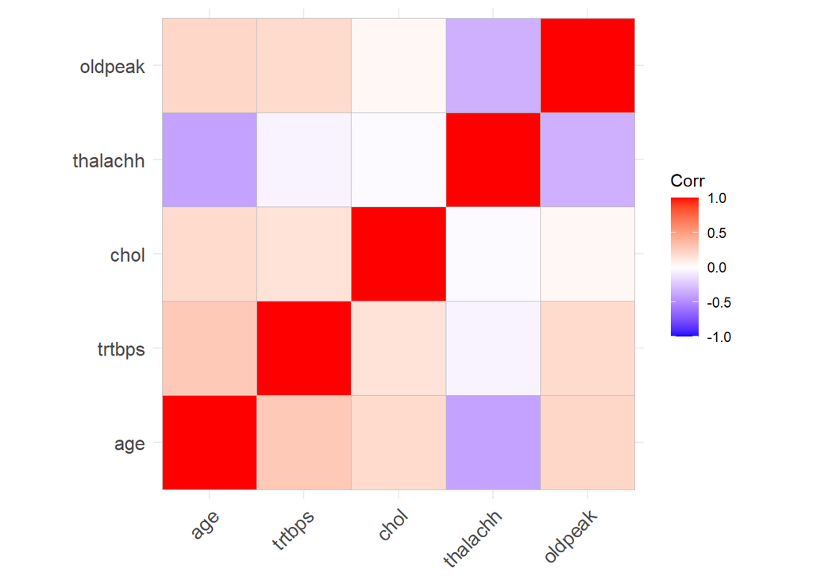

```r
numerical_data <- ds[10:14]
data_normalized <- scale(numerical_data)
corr_matrix <- cor(data_normalized)
ggcorrplot(corr_matrix)
```

```r
data.pca <- princomp(corr_matrix)
summary(data.pca)
```

```
## Importance of components:
##                           Comp.1    Comp.2    Comp.3     Comp.4 Comp.5
## Standard deviation     0.7237748 0.4117721 0.3571720 0.29405280      0
## Proportion of Variance 0.5772801 0.1868501 0.1405836 0.09528626      0
## Cumulative Proportion  0.5772801 0.7641302 0.9047137 1.00000000      1
```

Extra: es genial tener los primeros 4 componentes, pero ¿qué significan realmente? Esto se puede responder explorando cómo se relacionan con cada columna utilizando las cargas de cada componente principal.

```r
data.pca$loadings[, 1:4]
```

```
##               Comp.1      Comp.2     Comp.3     Comp.4
## age       0.51853385  0.31246809  0.2593289  0.5990149
## trtbps    0.21024875 -0.04094717  0.7647701 -0.5929054
## chol      0.04928446  0.76618907 -0.3729530 -0.4627945
## thalachh -0.69149215 -0.08694997  0.1089146  0.0598035
## oldpeak   0.45423314 -0.55324591 -0.4437554 -0.2681215
```

¿Cómo interpretamos estos resultados? Por ejemplo, centrándonos en el Componente 1, debemos mencionar que el atributo “thalachh” impacta negativamente en el PCA y los otros factores de forma positiva. Y el mismo enfoque se aplica a los otros componentes.

# 5. Representación de los resultados

> Representación de los resultados a partir de tablas y gráficas. Este apartado se puede responder a lo largo de la práctica, sin necesidad de concentrar todas las representaciones en este punto de la práctica.

En el desarrollo del ejercicio se han ido utilizando diagramas representativos. Para seleccionar los más interesantes en cada caso, se ha utilizado como referencia la siguiente url: https://www.data-to-viz.com/

# 6. Resolución del problema

> A partir de los resultados obtenidos, ¿cuáles son las conclusiones? ¿Los resultados permiten responder al problema?

Y es más probable tener ataque al corazón (output = 1) cuando:

- Picos anteriores (oldpeak) son más cercano a 0
- Frecuencia cardiaca (thalachh) con valores entre 150y 170.
- Presión arterial en reposo está entre 100 y 140 Hg.
- Colesterol esta entre 205 y 265 mg/dl según BMI sensor
- Y edad entre 45 y 59 años.

Después de comprobar qqtest, shapiro test y levene test comprobamos que incumplimos la asunciones de que el dataset sea normal y tenga homogeneidad de varianza.

Respecto las variables numéricas y mediante el Whitney Test, pudimos comprobar que todos los atributos numéricos y la salida en el conjunto de datos provienen de poblaciones no idénticas. Podemos concluir que la diferencia entre la media de la población de salida y el atributo numérico correspondiente es estadísticamente significativa.

```r
heart.split <- initial_split(ds)
heart.train <- training(heart.split)
heart.test <- testing(heart.split)
#logistic regression having all the predictors.
heart.full <- glm(output~., data = heart.train, family = "binomial")
summary(heart.full)
```

```
##
## Call:
## glm(formula = output ~ ., family = "binomial", data = heart.train)
##
## Deviance Residuals:
##      Min        1Q    Median        3Q       Max
## -2.79415  -0.17456   0.02993   0.30144   2.28690
##
## Coefficients:
##               Estimate Std. Error z value Pr(>|z|)
## (Intercept)  2.233e+00  5.313e+00   0.420 0.674289
## sex1        -1.926e+00  7.523e-01  -2.561 0.010446 *
## cp1          1.022e+00  7.179e-01   1.423 0.154701
## cp2          3.428e+00  8.176e-01   4.193 2.75e-05 ***
## cp3          3.702e+00  1.084e+00   3.415 0.000639 ***
## fbs1         6.332e-01  8.201e-01   0.772 0.440067
## restecg1     8.176e-01  5.182e-01   1.578 0.114608
## restecg2    -1.233e+01  1.560e+03  -0.008 0.993697
## exng1       -8.989e-01  5.670e-01  -1.585 0.112895
## slp1        -6.190e-01  1.370e+00  -0.452 0.651415
## slp2         1.100e+00  1.452e+00   0.757 0.448833
## caa1        -2.991e+00  7.493e-01  -3.992 6.55e-05 ***
## caa2        -3.781e+00  1.094e+00  -3.456 0.000548 ***
## caa3        -2.586e+00  1.253e+00  -2.063 0.039117 *
## caa4         1.689e+00  1.849e+00   0.913 0.361037
## thall1       3.908e+00  4.001e+00   0.977 0.328649
## thall2       3.255e+00  3.924e+00   0.829 0.406842
## thall3       1.106e+00  3.912e+00   0.283 0.777307
## age          6.317e-03  3.280e-02   0.193 0.847291
## trtbps      -4.231e-02  1.605e-02  -2.636 0.008400 **
## chol         1.082e-03  6.627e-03   0.163 0.870288
## thalachh     1.215e-02  1.563e-02   0.777 0.436976
## oldpeak     -5.796e-01  3.358e-01  -1.726 0.084294 .
## ---
## Signif. codes:  0 '***' 0.001 '**' 0.01 '*' 0.05 '.' 0.1 ' ' 1
##
## (Dispersion parameter for binomial family taken to be 1)
##
##     Null deviance: 312.86  on 225  degrees of freedom
## Residual deviance: 110.02  on 203  degrees of freedom
## AIC: 156.02
##
## Number of Fisher Scoring iterations: 15
```

```r
# set engine
heart_model <- logistic_reg() %>%
  set_engine("glm")

# create recipe
heart_recipe <- recipe(output ~., data = heart.train) %>%
  step_rm(fbs) %>%
  step_rm(age) %>%
  step_rm(chol) %>%
  step_zv(all_predictors())

# build work flow
heart_wflow <- workflow() %>%
  add_model(heart_model) %>%
  add_recipe(heart_recipe)

# fit training data through the work flow
heart_fit <- heart_wflow %>%
  fit(data = heart.train)
heart.train.pred = predict(heart_fit, new_data = heart.train)

traincomp <- data.frame(heart.train$output, heart.train.pred)
colnames(traincomp) <- c("train.response", "train.prediction")

heart.roc <- roc(response = ordered(traincomp$train.response), predictor = ordered(traincomp$train.prediction))
```

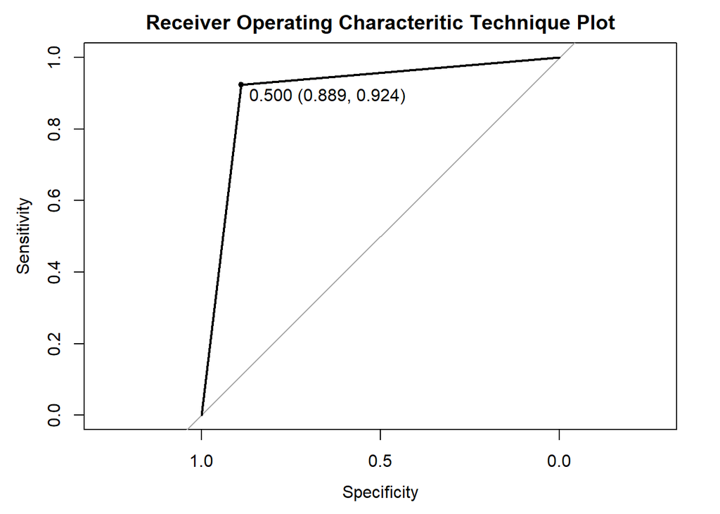

```r
plot(heart.roc, print.thres = "best", main = "Receiver Operating Characteritic Technique Plot")
```

```r
print(auc(heart.roc))
```

```
## Area under the curve: 0.9063
```

```r
#Perform 5-fold cross validation
set.seed(470)
folds <- vfold_cv(heart.train, v=5)

heart_fit_rs <- heart_wflow %>%
  fit_resamples(folds)
```

```
## → A | error:   factor restecg has new levels 2
```

[output not shown]

```r
metrics <- data.frame(collect_metrics(heart_fit_rs, summarize = FALSE))

metrics <- metrics %>%
  select(-.config)
colnames(metrics) <- c("Fold", "Metric", "Estimator", "Estimate")
metrics
```

```
##    Fold   Metric Estimator  Estimate
## 1 Fold1 accuracy    binary 0.7826087
## 2 Fold1  roc_auc    binary 0.8712121
## 3 Fold2 accuracy    binary 0.8888889
## 4 Fold2  roc_auc    binary 0.9700000
## 5 Fold3 accuracy    binary 0.8222222
## 6 Fold3  roc_auc    binary 0.8769841
## 7 Fold4 accuracy    binary 0.7777778
## 8 Fold4  roc_auc    binary 0.8952569
```

```r
# heart.test.pred = predict(heart_fit, new_data=heart.test, type="response")
#
# y_pred_num <- ifelse(heart.test.pred > 0.5, 1, 0)
# y_pred <- factor(y_pred_num, levels=c(0, 1))
# y_act <- testData$target
#
# # Result : Prediction Accuracy (Proportion of predicted target that matches with actual target)
# mean(y_pred == y_act)
```

```r
# #Generate predictions on testing data
# heart_disease_pred <- predict(heart_fit, new_data = heart.test) %>%
#   bind_cols(heart.test %>% select(output))
#
# test_accuracy <- accuracy(heart_disease_pred, truth = heart_disease, estimate = .pred_class)
# test_specificity <- spec(heart_disease_pred, truth = heart_disease, estimate = .pred_class)
# test_sensitivity <- sens(heart_disease_pred, truth = heart_disease, estimate = .pred_class)
#
# test.values <- data.frame(test_accuracy$.estimate, test_sensitivity$.estimate, test_specificity$.estimate)
# colnames(test.values) <- c("Test set Accuracy", "Test set Sensitivity", "Test set Specificity")
# test.values
```

# 7. Código

> Hay que adjuntar el código, preferiblemente en R, con el que se ha realizado la limpieza, análisis y representación de los datos. Si lo preferís, también podéis trabajar en Python.

Disponible en este mismo fichero.

# 8. Vídeo

> Realizar un breve vídeo explicativo de la práctica (máximo 10 minutos), donde ambos integrantes del equipo expliquen con sus propias palabras el desarrollo de la práctica, basándose en las preguntas del enunciado para justificar y explicar el código desarrollado. Este vídeo se deberá entregar a través de un enlace al Google Drive de la UOC ([https://drive.google.com/…),](https://drive.google.com/…),) junto con enlace al repositorio Git entregado.

Se puede visualizar en cualquiera de estas dos alternativas:

- Github: https://github.com/dcanete/heart
- Drive: https://drive.google.com/open?id=1gko9Vw2D3FQP5aewnnfp-hPio-AZ70KZ